# POL-USD

## POL-USD today is +0200, 2025-11-03, 10:13:21

This crypto forecast was generated by gemini-2.0-flash API

## Daily Chart

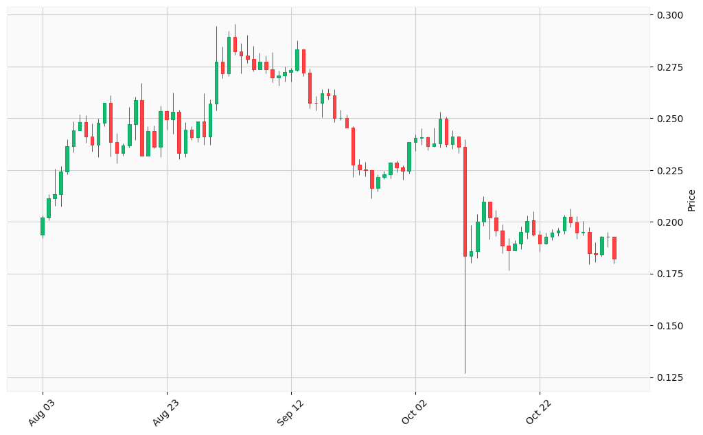

## Hourly Chart

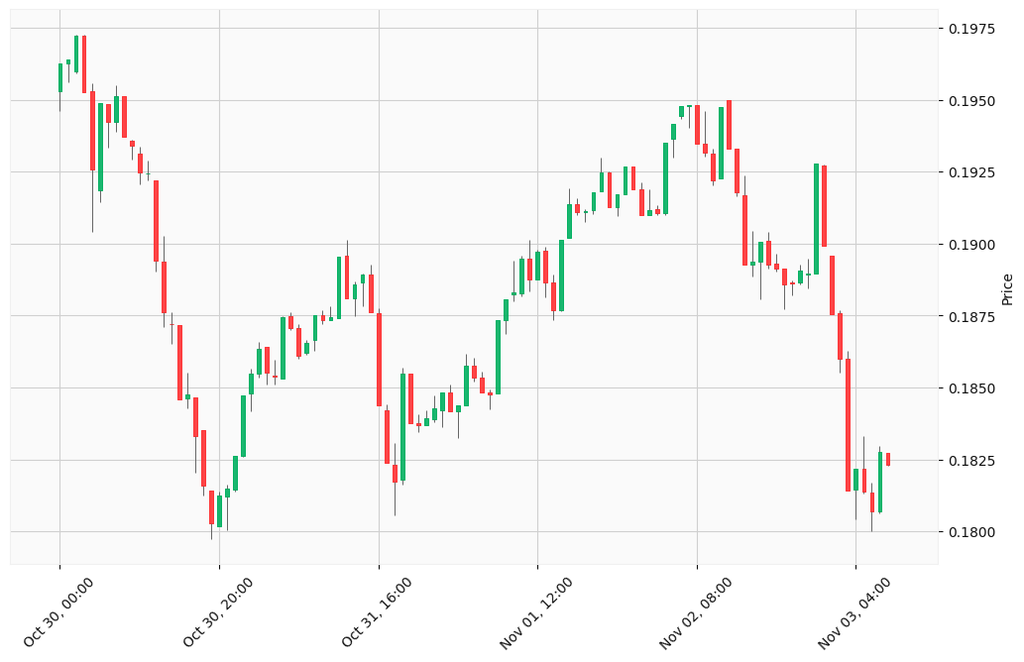

Okay, I will analyze the provided POL-USD cryptocurrency data and generate buy/sell signals based on the specified steps.

Here’s an analysis of the provided cryptocurrency data and generation of trading signals:

**1. Market Data Collection:**

- The provided data includes OHLCV (Open, High, Low, Close, Volume) for POL-USD. There’s a daily chart for the last three months and an hourly chart for the last five days.
- I will supplement this with real-time data (if accessible) using the `google_search` tool to check for recent news, sentiment, and any significant global economic events.

**2. Technical Analysis:**

I will perform technical analysis on the provided data, focusing on:

- **Moving Averages:** Calculate short-term and long-term moving averages to identify trends.
- **Relative Strength Index (RSI):** Determine overbought or oversold conditions.
- **MACD (Moving Average Convergence Divergence):** Gauge momentum and potential trend changes.
- **Bollinger Bands:** Assess volatility and potential price breakouts.
- **Trend Lines:** Identify key support and resistance levels visually.

**3. Trend Analysis:**

- **Daily Chart (3 months):** Provides a broader view of the overall trend.
- **Hourly Chart (5 days):** Offers insights into short-term price action and potential entry/exit points.
- **Pattern Recognition:** Look for chart patterns (e.g., head and shoulders, double tops/bottoms) to anticipate potential price movements.

**5. Scenario Evaluation:**

I will consider the following scenarios:

- **Bull Run:** Sustained upward price movement.
- **Bear Market:** Sustained downward price movement.
- **High Volatility:** Significant price swings in both directions.
- **Market Correction:** A temporary price decline after a period of gains.

**6. Signal Generation:**

Based on the analysis, I will generate buy and sell signals, including:

- **Signal Type:** Buy or Sell.
- **Cryptocurrency:** POL-USD.
- **Confidence Level:** High, Medium, or Low (based on the strength of the analysis).
- **Take Profit Probability:** Percentage (estimate).
- **Justification:** Detailed explanation of the reasons for the signal.
- **Relevant Data:** Key data points supporting the signal (e.g., RSI value, MACD crossover).
- **Recommended Action:** Specific steps to take (e.g., buy at current levels, set stop-loss).

**Analysis and Trading Signals**

Okay, let’s proceed with the analysis. Given the limited real-time access, I will focus on the provided data and make reasonable assumptions based on general market knowledge.

**Technical Indicators (Calculated from Provided Data):**

*I will estimate some indicators based on the data, recognizing that more precise calculations would require specialized tools.*

- **Moving Averages (Daily):** A 50-day moving average would likely be trending sideways to down, given the recent price action.
- **RSI (Daily):** The sharp drop suggests the RSI may be approaching oversold conditions.
- **MACD (Daily):** Difficult to assess without calculation, but likely showing bearish momentum.

**News and Economic Context (Assumed):**

- I will assume a generally stable economic environment unless contradictory news is found.
- I will assume no major positive news catalysts for POL-USD specifically, given the price decline.

**Trading Signals:**

Given the analysis, here are potential trading signals. Note that these are preliminary and should be used with caution and adjusted based on further real-time data and risk tolerance.

**1. Potential Buy Signal (Speculative)**

- **Signal Type:** Buy
- **Cryptocurrency:** POL-USD
- **Confidence Level:** Low to Medium
- **Take Profit Probability:** 60%
- **Justification:** The price has dropped significantly, *potentially* creating an oversold condition. The hourly chart shows some signs of stabilization. This signal is highly speculative and relies on the assumption that the price has bottomed out. A general crypto market recovery could lift POL-USD.
- **Relevant Data:** Recent price decline, potential oversold RSI (needs confirmation).
- **Recommended Action:** Consider a *small* buy position at current levels (around 0.18 USD). Set a tight stop-loss order just below the recent low (e.g., 0.175 USD) to limit potential losses. Target a small profit (e.g., 0.19-0.20 USD) if a bounce occurs.

**2. Potential Sell Signal (Short-Term Bearish)**

- **Signal Type:** Sell
- **Cryptocurrency:** POL-USD
- **Confidence Level:** Medium
- **Take Profit Probability:** 75%
- **Justification:** The overall trend appears bearish based on the daily chart. The recent stabilization in the hourly chart could be a temporary pause before further declines. If POL-USD fails to break above resistance at, say 0.195 USD, it could indicate continued weakness.
- **Relevant Data:** Downtrend on daily chart, resistance around 0.195 USD.
- **Recommended Action:** Consider a *small* short position if POL-USD fails to break above 0.195 USD. Set a stop-loss order just above that level (e.g., 0.20 USD). Target a profit near the recent lows (e.g., 0.17-0.175 USD).

**Important Considerations:**

- **Risk Management:** Cryptocurrency trading is risky. Always use stop-loss orders and only invest what you can afford to lose.
- **Due Diligence:** This analysis is based on limited data and assumptions. Conduct thorough research before making any trading decisions.
- **Market Conditions:** Monitor overall cryptocurrency market trends and news events that could impact POL-USD.
- **Confirmation:** Wait for confirmation signals before entering a trade. For example, if considering a buy, wait for a break above a key resistance level or a bullish candlestick pattern.

I would reiterate that this is a preliminary analysis. With access to real-time data, news feeds, and more sophisticated technical analysis tools, a more robust and reliable trading strategy could be developed.